# Simulations varying freq. of E

Andrey Ziyatdinov

2016-12-14

# 1 Is there any bias?

## 1.1 Default simulation: `famgen`, int 0.1, var 0.6, freq_e 0.3

```
 *** Input parameters ***
 - num_total 2,500: num_fam 500, size_fam 5
 - num_sim_null 20,000, num_sim_alt 10,000
 - sim_gen 'rbinom_fam', sim_phen 'famgen'; fit 'relmatLmer'
 - var_fam 0.3, var_gen 0.3; var_explained 0.6
 - int 0.1; freq_g 0.3; freq_e 0.3
 *** Output ***
 - power: total 0.447, strat_uncor 0.296, strat_cor 0.358 (rho_strat 0.167)
```

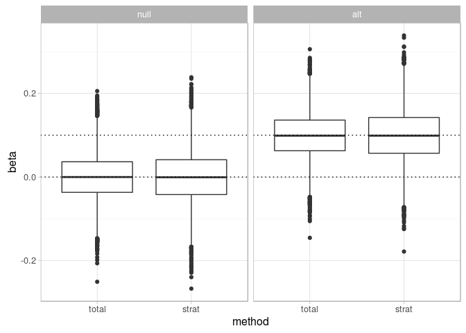

## 1.2 Other default simulations: `sim_phen`

Observations:

- `no_rand` has the lowest variance in effect estimations (see red lines on the figure).
- Both `no_rand` and `fam_envfam` have similar variance between two methods, `total` and `strat`.
  - Where is the loss in power in the case of `fam_envfam`?
- Modes `fam`, `gen` and `famgen` show difference variance between `total` and `strat`.
  - Why these three modes are different to `fam_envfam` (which is also a random-effect mode).

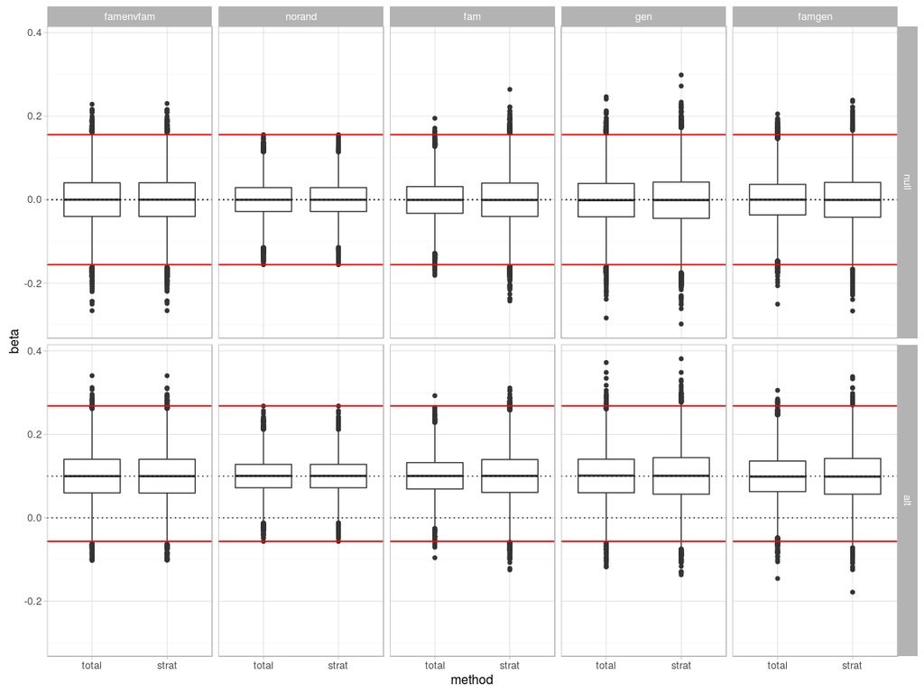

# 2 Where is the loss in power?

## 2.1 Power for the default simulations

Both table (`int` 0.1) and figure (a range of `int` values) given below are copied from the previous report 01-famgen.html.

| sim_phen | power_total | power_strat_cor | power_strat_uncor | rho_strat | num_sim_alt | alpha |
| --- | --- | --- | --- | --- | --- | --- |
| fam_envfam | 0.3852 | 0.3864 | 0.3852 | 0.0042 | 10,000 | 0.05 |
| no_rand | 0.6566 | 0.6568 | 0.6577 | -0.0020 | 10,000 | 0.05 |
| fam | 0.5716 | 0.4020 | 0.3547 | 0.1221 | 10,000 | 0.05 |
| famgen | 0.4468 | 0.3579 | 0.2961 | 0.1670 | 10,000 | 0.05 |
| gen | 0.3916 | 0.3449 | 0.2832 | 0.1608 | 10,000 | 0.05 |

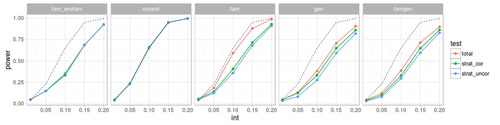

## 2.2 Formulas

### 2.2.1 Linear model

$Y \sim \mathcal{N}(\mu 1_n + X \beta, \sigma_e^2 I)$

$\hat{\beta} = (X^T X)^{−1} X^T Y \simeq \mathcal{N}(\beta, \frac{\sigma_e^2}{X^T X})$

$\hat{\mu} = \frac{1_n^T X}{X^T X}$

$\hat{e} = Y − \hat{\mu} 1_n - X \hat{\beta}$

$\hat{\sigma_e} = \sqrt{\frac{\hat{e}^T \hat{e}}{n - 2}}$

### 2.2.2 Power in linear model

Non-centrality parameter for the $\chi^2$ test:

$\lambda = \frac{\beta^2 X^T X}{\sigma_e^2} n$

### 2.2.3 Scores in linear model

$T = \frac{\hat{\beta}}{\hat{\sigma_e}} \sqrt{X^T X} \simeq \mathcal{N}(\beta \frac{\sigma_e^2}{X^T X}, 1)$

Covariance of two scores in meta-analysis:

$cov(T_0, T_1) = \frac{X_0^T cov(Y_0, Y_1) X_1}{\sqrt{X_0^T X_0 \sigma_{e_0}^2} \sqrt{X_1^T X_1 \sigma_{e_1}^2}}$

- In a single cohort, for example, to describe the distribution of scores needed for multiple test correction (Joo et al. 2016): $cov(T_0, T_1) = cov(X_0, X_1)$
- In different cohorts or phenotypes for meta-analysis (Zhu et al. 2015): $cov(T_0, T_1) = cov(Y_0, Y_1)$

### 2.2.4 Linear mixed model

$Y \sim \mathcal{N}(\mu 1_n + X \beta, \sigma_g^2 K + \sigma_e^2 I)$

$cov(Y) = \hat{V} = \hat{\sigma}_g^2 K + \hat{\sigma}_e^2 I$

WLS comes on the scene and now we can make use of OLS with an transformation:

$\hat{V}^{-0.5} Y \sim \mathcal{N}(\hat{V}^{-0.5} \mu 1_n + \hat{V}^{-0.5} X \beta, I)$

Note that the sigma-parameter for the residual variance is now equal `1`.

For example,

$\hat{\beta} = (X^T \hat{V}^{-1} X)^{−1} X^T \hat{V}^{-1} Y \simeq \mathcal{N}(\beta, \frac{\sigma_e^2}{X^T \hat{V}^{-1} X})$

$cov(T_0, T_1) = \frac{\hat{V}^{-0.5} X_0^T cov(\hat{V}^{-0.5} Y_0, \hat{V}^{-0.5} Y_1) X_1}{\sqrt{X_0^T \hat{V}^{-1} X_0} \sqrt{X_1^T \hat{V}^{-1} X_1}}$

References

Joo, Jong Wha J, Farhad Hormozdiari, Buhm Han, and Eleazar Eskin. 2016. “Multiple Testing Correction in Linear Mixed Models.” *Genome Biology* 17 (1). BioMed Central: 1.

Zhu, Xiaofeng, Tao Feng, Bamidele O Tayo, Jingjing Liang, J Hunter Young, Nora Franceschini, Jennifer A Smith, et al. 2015. “Meta-Analysis of Correlated Traits via Summary Statistics from GWASs with an Application in Hypertension.” *The American Journal of Human Genetics* 96 (1). Elsevier: 21–36.